# Strategic Performance Analysis

2026-03-06

## Project Objective

**Translating Statistical Learning into Business Decisions**

The objective is to optimize the marketing portfolio. Exploratory Data Analysis (EDA), K-Means Clustering, and Random Forest models reveal clear patterns in budget behavior.

**Our Strategic Focus:**

- **Risk Management:** Identifying stable returns versus high-volatility environments.
- **Cost Neutrality:** Evaluating the actual impact of industry sectors on acquisition costs.
- **Segmentation:** Identifying hidden groupings in how campaigns scale and profit.
- **Drivers of Revenue:** Isolating the true metrics that generate income.

## 1. Baseline Health: The Zero-Waste Reality

### Insight: The foundational strategy is already profitable.

**Business Implication:** The portfolio does not suffer from structural failures, fraudulent bot-traffic drains, or broken conversion tracking. The strategic mandate is purely focused on **margin optimization**.

## 2. Platform Risk vs. Reward

### Insight: Volatility differs drastically by platform.

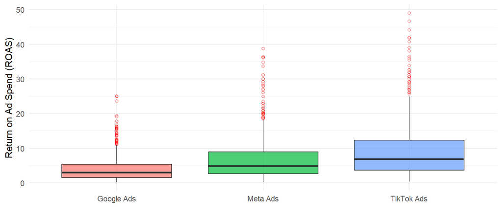

**Business Implication:** TikTok Ads exhibit the highest median return but possess a massive variance. Google Ads operates as a highly compacted, conservative environment. Different platforms require different risk tolerances.

## 3. The “Industry Neutrality” Concept

### Insight: Competition costs are sector-agnostic.

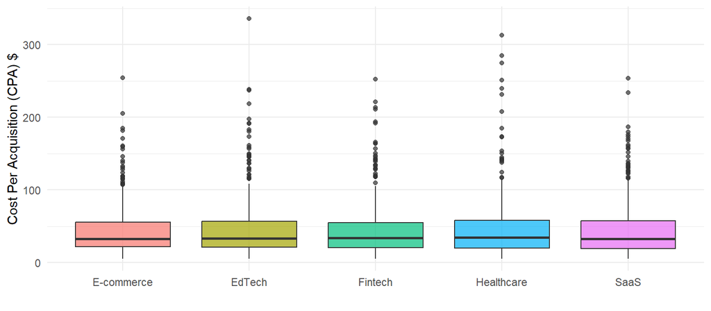

## 4. Campaign Format Glossary

### Understanding Our Marketing Arsenal

Before diving into formatting and segmentation, here is how we classify our campaigns:

- **Search:** Text-based ads triggered by user search queries. Captures immediate, high-intent demand.
- **Display:** Visual banner ads placed across websites and blogs. Drives mass awareness and brand recall.
- **Video:** Pre-roll or mid-roll video advertisements. Generates high engagement through storytelling.
- **Shopping:** Product listings showing image, price, and store directly in search results. Focused on frictionless conversions.

## 5. Format Efficiency and Scalability

### Insight: Efficiency decay varies by campaign type.

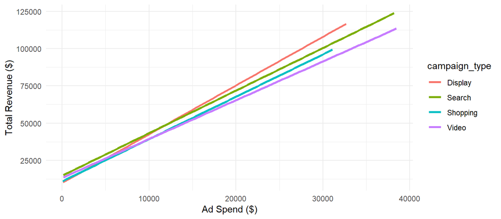

## 6. Unsupervised Insights: The Two Dimensions

### Insight: Complexity boils down to Scale vs. Efficiency.

**Business Implication:** We must stop evaluating campaigns on vanity metrics. A campaign is only defined by how big it is (Scale) and how profitable it is (Efficiency).

## 7. Unsupervised Insights: The 4 Segments

### Insight: K-Means reveals 4 distinct campaign profiles.

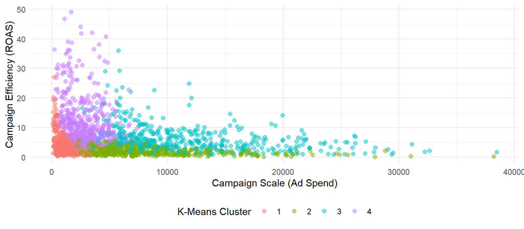

## 8. Supervised Insights: Revenue Drivers

### Insight: Interactivity outweighs exposure.

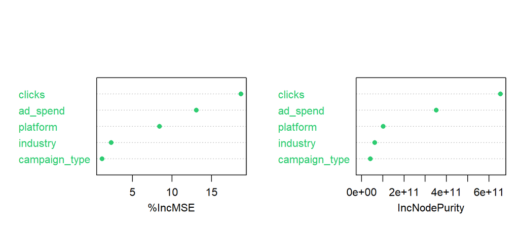

## 9. Action 1: The 70/30 Risk Split

### Objective: Balance guaranteed returns with aggressive growth.

**Implementation Plan:**

- **70% Core Allocation (Google Ads):** Direct the majority of the daily budget into the low-variance environment. This secures the baseline revenue targets regardless of market fluctuations.
- **30% Venture Allocation (TikTok Ads):** Deploy the remaining funds specifically to hunt for extreme, high-ROAS outliers.

**The Rationale:** Allocating 100% to TikTok introduces unacceptable mathematical variance to quarterly targets, while 100% in Google leaves potential profit on the table.

## 10. Action 2: Halt Video Format Scaling

### Objective: Protect profit margins from diminishing returns.

**Implementation Plan:**

- **Establish Budget Ceilings:** Enforce a hard spending cap on “Video” and “Shopping” campaigns to prevent efficiency decay.
- **Automated Re-routing:** Once a Video campaign reaches its optimal spend threshold (before the slope flattens), automatically redirect surplus budget into “Search” and “Display” pipelines.

## 11. Action 3: The CPC Pivot

### Objective: Align bidding mechanics with algorithmic predictors.

**Implementation Plan:**

- **Phase Out CPM:** Aggressively deprecate all campaigns currently paying for visual exposure (Cost-Per-Mille / Impressions).
- **Transition to CPC:** Restructure the portfolio to exclusively utilize Cost-Per-Click bidding.

## 12. Action 4: The Quadrant Strategy

### Objective: Manage campaigns by algorithmic segments, not manually.

**Implementation Plan:**

We will apply strict management rules to the 4 clusters identified by the K-Means algorithm:

- **High Scale / High Efficiency (The Stars):** Remove all budget caps. Feed these campaigns algorithmically until ROAS begins to drop.
- **High Scale / Low Efficiency (The Bleeders):** Immediately trigger a creative audit. These campaigns are spending aggressively but destroying margin.
- **Low Scale / High Efficiency (The Hidden Gems):** Incrementally increase budget by 15% week-over-week. They are profitable but artificially constrained by low spend.
- **Low Scale / Low Efficiency (The Losers):** Pause immediately. Do not attempt to optimize.